# N736: Lesson 23 - RM ANOVA and MLM

Melinda K. Higgins, PhD.

November 14, 2017

In this lesson, N736 Lesson 23 - Repeated Measures ANOVA and Multilevel (Mixed) Linear Models (MLM), we’re going to add a BETWEEN group variable treat and look at multilevel (mixed) model approach.

We’re working with the `helpmkh` dataset

```r
library(tidyverse)
library(haven)

helpdat <- haven::read_spss("helpmkh.sav")

h1 <- helpdat %>%
  select(id, treat, pcs, pcs1, pcs2, pcs3, pcs4)
```

In `R` we need to restructure the data from a WIDE into a LONG format, where time is added as a variable (in a column) - so, since we have 5 time points each subject will have 5 rows of data. We accomplish this using the `gather()` function from the `tidyr` package, which was loaded with `tidyverse` above.

```r
# restructure into long format
h1long <- h1 %>%
  gather(key=item,
         value=value,
         -c(id,treat))

# rename the variables
names(h1long) <- c("id","treat","pcsitem","pcsvalue")

# add a time variable to long format
h1long <- h1long %>%
  mutate(time=c(rep(0,453),
                rep(1,453),
                rep(2,453),
                rep(3,453),
                rep(4,453)))
```

## From the “Cookbook for R” - Making an Error Bar Plot - Means Over Time

See the article at http://www.cookbook-r.com/Graphs/Plotting_means_and_error_bars_(ggplot2)/ to get the code for the `summarySE` function.

This function gives count, mean, standard deviation, standard error of the mean, and confidence interval (default 95%):

- `data`: a data frame.
- `measurevar`: the name of a column that contains the variable to be summariezed
- `groupvars`: a vector containing names of columns that contain grouping variables
- `na.rm`: a boolean that indicates whether to ignore NA’s
- `conf.interval`: the percent range of the confidence interval (default is 95%)

```r
summarySE <- function(data=NULL, measurevar, groupvars=NULL, na.rm=FALSE,
                      conf.interval=.95, .drop=TRUE) {
  library(plyr)

  # New version of length which can handle NA's: if na.rm==T, don't count them
  length2 <- function (x, na.rm=FALSE) {
    if (na.rm) sum(!is.na(x))
    else       length(x)
  }

  # This does the summary. For each group's data frame, return a vector with
  # N, mean, and sd
  datac <- ddply(data, groupvars, .drop=.drop,
                 .fun = function(xx, col) {
                   c(N    = length2(xx[[col]], na.rm=na.rm),
                     mean = mean   (xx[[col]], na.rm=na.rm),
                     sd   = sd     (xx[[col]], na.rm=na.rm)
                   )
                 },
                 measurevar
  )

  # Rename the "mean" column
  datac <- rename(datac, c("mean" = measurevar))

  datac$se <- datac$sd / sqrt(datac$N)  # Calculate standard error of the mean

  # Confidence interval multiplier for standard error
  # Calculate t-statistic for confidence interval:
  # e.g., if conf.interval is .95, use .975 (above/below), and use df=N-1
  ciMult <- qt(conf.interval/2 + .5, datac$N-1)
  datac$ci <- datac$se * ciMult

  return(datac)
}
```

This function is then used to create a error bar plot of the means over time and by `treat` group.

```r
# remove NA's missing values
h1long_nomiss <- na.omit(h1long)

# see how many values at each time point
table(h1long_nomiss$time)
```

```
##
##   0   1   2   3   4
## 453 246 211 248 266
```

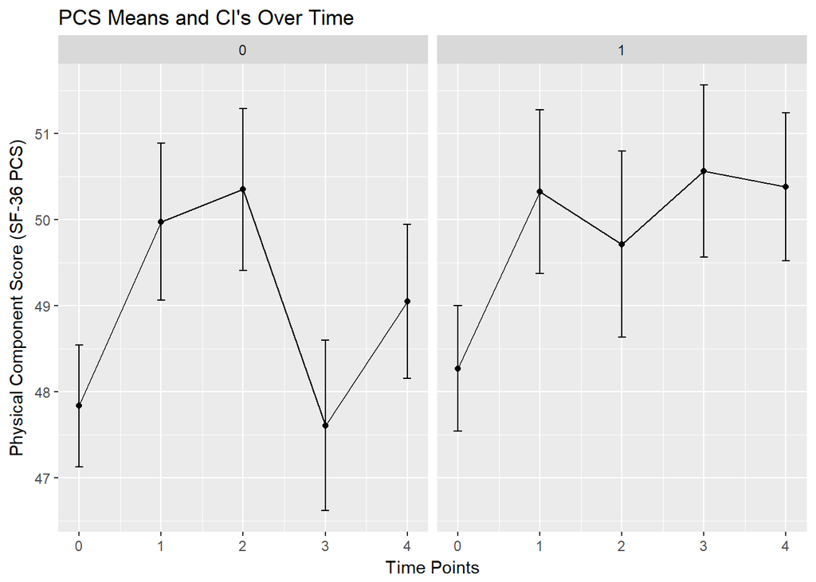

```r
# get summary stats using the summarySE function
h1se <- summarySE(h1long_nomiss,
                  measurevar="pcsvalue",
                  groupvars=c("time","treat"))

# make plot
ggplot(h1se, aes(x=time, y=pcsvalue)) +
  geom_errorbar(aes(ymin=pcsvalue-se, ymax=pcsvalue+se), width=.1) +
  geom_line() +
  geom_point() +
  xlab("Time Points") +
  ylab("Physical Component Score (SF-36 PCS)") +
  ggtitle("PCS Means and CI's Over Time") +
  facet_wrap(~treat)
```

## Multilevel (MIXED) Linear Modeling Approach

There are 2 main packages for R to do MLM - either `nlme` or `lme4`. You can read more at https://freshbiostats.wordpress.com/2013/07/28/mixed-models-in-r-lme4-nlme-both/. You can also google “nlme vs lme4 package”.

```r
# use nlme package
library(nlme)

lme1 <- lme(pcsvalue ~ time*treat,
            data=h1long,
            random= ~1 | id,
            method="REML",
            na.action=na.omit)

# get summary - model coefficients
# tests coefficients not equal to 0
summary(lme1)
```

```
## Linear mixed-effects model fit by REML
##  Data: h1long
##        AIC      BIC    logLik
##   10371.37 10402.92 -5179.683
##
## Random effects:
##  Formula: ~1 | id
##         (Intercept) Residual
## StdDev:    7.556092 7.370726
##
## Fixed effects: pcsvalue ~ time * treat
##                Value Std.Error  DF  t-value p-value
## (Intercept) 48.38795 0.6597472 969 73.34316  0.0000
## time         0.32167 0.1959805 969  1.64133  0.1011
## treat        0.47908 0.9327978 451  0.51359  0.6078
## time:treat   0.17601 0.2716827 969  0.64785  0.5172
##  Correlation:
##            (Intr) time   treat
## time       -0.453
## treat      -0.707  0.321
## time:treat  0.327 -0.721 -0.458
##
## Standardized Within-Group Residuals:
##         Min          Q1         Med          Q3         Max
## -4.03510174 -0.52573726  0.07718642  0.57373372  2.78446316
##
## Number of Observations: 1424
## Number of Groups: 453
```

```r
# get anova tables - both
# of these yield type III Sums of Squares
anova.lme(lme1, type="marginal")
```

```
##             numDF denDF  F-value p-value
## (Intercept)     1   969 5379.220  <.0001
## time            1   969    2.694  0.1011
## treat           1   451    0.264  0.6078
## time:treat      1   969    0.420  0.5172
```

```r
car::Anova(lme1, type="III")
```

```
## Analysis of Deviance Table (Type III tests)
##
## Response: pcsvalue
##                 Chisq Df Pr(>Chisq)
## (Intercept) 5379.2197  1     <2e-16 ***
## time           2.6940  1     0.1007
## treat          0.2638  1     0.6075
## time:treat     0.4197  1     0.5171
## ---
## Signif. codes:  0 '***' 0.001 '**' 0.01 '*' 0.05 '.' 0.1 ' ' 1
```

```r
# FYI - sequential SS or Type II SS
anova.lme(lme1, type="sequential")
```

```
##             numDF denDF   F-value p-value
## (Intercept)     1   969 14126.251  <.0001
## time            1   969     9.359  0.0023
## treat           1   451     0.830  0.3627
## time:treat      1   969     0.420  0.5172
```

```r
car::Anova(lme1, type="II")
```

```
## Analysis of Deviance Table (Type II tests)
##
## Response: pcsvalue
##             Chisq Df Pr(>Chisq)
## time       9.2703  1   0.002329 **
## treat      0.8303  1   0.362194
## time:treat 0.4197  1   0.517084
## ---
## Signif. codes:  0 '***' 0.001 '**' 0.01 '*' 0.05 '.' 0.1 ' ' 1
```

Flip the coding for the `treat` group also and compare the results.

```r
# flip treat and run again
h1long <- h1long %>%
  mutate(treat_flip = as.numeric(treat==0))

lme2 <- lme(pcsvalue ~ time*treat_flip,
            data=h1long,
            random= ~1 | id,
            method="REML",
            na.action=na.omit)

# get summary - model coefficients
# tests coefficients not equal to 0
summary(lme2)
```

```
## Linear mixed-effects model fit by REML
##  Data: h1long
##        AIC      BIC    logLik
##   10371.37 10402.92 -5179.683
##
## Random effects:
##  Formula: ~1 | id
##         (Intercept) Residual
## StdDev:    7.556092 7.370726
##
## Fixed effects: pcsvalue ~ time * treat_flip
##                    Value Std.Error  DF  t-value p-value
## (Intercept)     48.86703 0.6594280 969 74.10517  0.0000
## time             0.49768 0.1881573 969  2.64501  0.0083
## treat_flip      -0.47908 0.9327978 451 -0.51359  0.6078
## time:treat_flip -0.17601 0.2716827 969 -0.64785  0.5172
##  Correlation:
##                 (Intr) time   trt_fl
## time            -0.462
## treat_flip      -0.707  0.327
## time:treat_flip  0.320 -0.693 -0.458
##
## Standardized Within-Group Residuals:
##         Min          Q1         Med          Q3         Max
## -4.03510174 -0.52573726  0.07718642  0.57373372  2.78446316
##
## Number of Observations: 1424
## Number of Groups: 453
```

```r
# get anova tables - both
# of these yield type III Sums of Squares
anova.lme(lme2, type="marginal")
```

```
##                 numDF denDF  F-value p-value
## (Intercept)         1   969 5491.577  <.0001
## time                1   969    6.996  0.0083
## treat_flip          1   451    0.264  0.6078
## time:treat_flip     1   969    0.420  0.5172
```

```r
car::Anova(lme2, type="III")
```

```
## Analysis of Deviance Table (Type III tests)
##
## Response: pcsvalue
##                     Chisq Df Pr(>Chisq)
## (Intercept)     5491.5769  1  < 2.2e-16 ***
## time               6.9961  1   0.008169 **
## treat_flip         0.2638  1   0.607535
## time:treat_flip    0.4197  1   0.517084
## ---
## Signif. codes:  0 '***' 0.001 '**' 0.01 '*' 0.05 '.' 0.1 ' ' 1
```